# Convergence with respect to maximum multipole order of individual scatterers

02 October, 2021

## Objective

This example checks the convergence of orientation-averaged cross-sections with respect the maximum multipolar order describing individual scatterers. The structure consists of four gold spheres in water arranged in a helix.

This simulation uses the following `input` file

```
ModeAndScheme 2 3
MultipoleCutoff 6
Wavelength 400 700 150
Medium 1.7689 # epsilon of water
OutputFormat HDF5 cross_sections_{nmax}

MultipoleSelections 1
EE1:{nmax}_EM1:{nmax}_ME1:{nmax}_MM1:{nmax} blocks

Scatterers 4
Au_S1 100.0000  0.00000 -30 25.0
Au_S1  80.9017 58.77853 -10 25.0
Au_S1  30.9017 95.10565  10 25.0
Au_S1 -30.9017 95.10565  30 25.0
```

where `{nmax}` is replaced by `1,2,3,...` in each separate run.

```
Rows: 15,855
Columns: 6
$ nmax       <chr> "1", "1", "1", "1", "1", "1", "1", "1", "1", "1", "1", "1",…
$ wavelength <dbl> 400, 402, 404, 406, 408, 410, 412, 414, 416, 418, 420, 422,…
$ crosstype  <chr> "Abs", "Abs", "Abs", "Abs", "Abs", "Abs", "Abs", "Abs", "Ab…
$ variable   <fct> total, total, total, total, total, total, total, total, tot…
$ dichroism  <dbl> 0.8899669, 0.9016020, 0.9131909, 0.9246548, 0.9359208, 0.94…
$ average    <dbl> 12481.17, 12461.23, 12440.24, 12418.38, 12395.84, 12372.83,…
```

## Convergence with Nmax

We see that in this example the cross-sections converge after only a few multipoles, and that the dipole term gives already a reasonable approximation of the spectral lineshape,

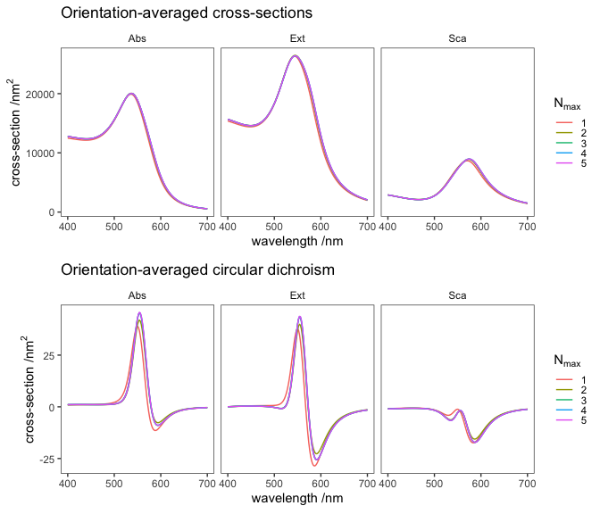

## Convergence with “MultipoleOrder”

The study above used masking of individual T-matrices to restrict the maximum Nmax, keeping `MultipoleOrder = 6` constant in all simulations. This is more meaningful, since the `MultipoleOrder` keyword refers to the order of expansions in the multiple scattering calculation, which typically requires a larger cutoff to accurately translate spherical waves from one origin to another. If we were to look at the individual contributions of the multipoles appearing in the cluster’s expansion as a whole, the convergence looks very different (and arguably has a less physical interpretation).

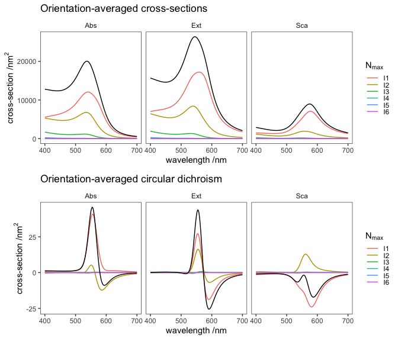

*Last run: 02 October, 2021*